# ImuDataExplore_JLaframboise

## Data Exploration of IMU Data from TurtleBot3

#### By Jacob Laframboise

This data was collected from RVis in a Gazebo simulation of a TurtleBot3 Waffle Pi robot through ROS. The robot was driving on flat surfaces in the 'house' default world for ROS simulation.

```python
import pandas as pd
import numpy as np
import seaborn as sns
import matplotlib.pyplot as plt
import pandas_profiling as pp

%matplotlib inline
```

```python
df= pd.read_csv('subsetBag.csv')
df = df.set_index(['Seq'])
df.head()
```

| Seq | Secs | Nanosecs | OrientX | OrientY | OrientZ | OrientW | AngVelX | AngVelY | AngVelZ | AccelX | AccelY | AccelZ |
| --- | --- | --- | --- | --- | --- | --- | --- | --- | --- | --- | --- | --- |
| 0.0 | 1324.0 | 514000000.0 | 0.001044 | 0.001202 | -0.657056 | 0.753840 | 0.000015 | 0.000061 | -0.000262 | 7.743543e-08 | 4.039488e-08 | 4.467783e-06 |
| 1.0 | 1324.0 | 518000000.0 | 0.001044 | 0.001202 | -0.657056 | 0.753840 | 0.000015 | 0.000061 | -0.000262 | -1.734290e-08 | -3.004739e-08 | -1.162637e-10 |
| 2.0 | 1324.0 | 523000000.0 | 0.001044 | 0.001202 | -0.657057 | 0.753839 | 0.000015 | 0.000061 | -0.000262 | -1.734162e-08 | -3.005706e-08 | -1.165548e-10 |
| 3.0 | 1324.0 | 528000000.0 | 0.001044 | 0.001202 | -0.657057 | 0.753839 | 0.000015 | 0.000061 | -0.000262 | -1.734996e-08 | -3.005905e-08 | -1.174085e-10 |
| 4.0 | 1324.0 | 533000000.0 | 0.001044 | 0.001202 | -0.657058 | 0.753839 | 0.000015 | 0.000061 | -0.000262 | -1.735201e-08 | -3.005913e-08 | -1.175825e-10 |

```python
df.describe()
```

|  | Secs | Nanosecs | OrientX | OrientY | OrientZ | OrientW | AngVelX | AngVelY | AngVelZ | AccelX | AccelY | AccelZ |
| --- | --- | --- | --- | --- | --- | --- | --- | --- | --- | --- | --- | --- |
| count | 24366.000000 | 2.436600e+04 | 24366.000000 | 24366.000000 | 24366.000000 | 24366.000000 | 24366.000000 | 24366.000000 | 24366.000000 | 2.436600e+04 | 2.436600e+04 | 2.436600e+04 |
| mean | 1384.932939 | 5.004983e+08 | 0.000652 | 0.000571 | -0.409955 | 0.358103 | 0.000034 | 0.000068 | -0.069091 | 2.112850e-03 | 9.612513e-04 | 6.406907e-07 |
| std | 35.175147 | 2.888570e+08 | 0.000988 | 0.000897 | 0.621573 | 0.563358 | 0.003581 | 0.000923 | 0.286007 | 3.543796e-01 | 2.593589e-01 | 1.332036e-02 |
| min | 1324.000000 | 1.000000e+06 | -0.001587 | -0.001590 | -0.999999 | -0.999999 | -0.545459 | -0.016366 | -1.417108 | -3.975749e+01 | -1.253969e+00 | -1.063808e+00 |
| 25% | 1354.000000 | 2.480000e+08 | 0.001026 | -0.000138 | -0.665163 | -0.087548 | -0.000008 | 0.000015 | -0.021398 | -1.452808e-06 | -2.480055e-05 | -8.173077e-06 |
| 50% | 1385.000000 | 5.030000e+08 | 0.001047 | 0.001197 | -0.658515 | 0.750835 | 0.000015 | 0.000061 | -0.000260 | -1.740837e-08 | -2.949089e-08 | -1.198066e-10 |
| 75% | 1415.000000 | 7.520000e+08 | 0.001057 | 0.001200 | -0.645476 | 0.752712 | 0.000020 | 0.000071 | -0.000256 | 1.000173e-04 | 1.608361e-08 | 4.460768e-08 |
| max | 1446.000000 | 9.990000e+08 | 0.001593 | 0.001232 | 0.999999 | 0.774419 | 0.024697 | 0.087305 | 1.446494 | 3.122140e+01 | 2.237614e+01 | 6.055230e-01 |

We have acceleration at each time, and so we can use the fact that velocity is the first integral of acceleration, and position is the second integral of acceleration. Since our acceleration is not determined by a function, we use an implementation of a Riemann sum to find the area under the curve, ie. the velocity and position. This is computed below for all directions.

```python
# compute the magnitude of the direction vector at each point
df['AccelMag'] = np.sqrt(df['AccelX']**2 + df['AccelY']**2 +df['AccelZ']**2)
# compute the time elapsed since the last frame
df['DeltaT'] = pd.Series([ df.Secs.iloc[i]+df.Nanosecs.iloc[i]/10**9 - df.Secs.iloc[i-1] - df.Nanosecs.iloc[i-1]/10**9 if i>0 else 4000000.0/10**9 for i in range(len(df.index))])

# compute velocity at each time in each direction.
df['DeltaLinVelX'] = df['DeltaT']*df['AccelX']
df['CurrentVelX'] = pd.Series([df.DeltaLinVelX.iloc[0:i].sum() for i in range(len(df.index))])

df['DeltaLinVelY'] = df['DeltaT']*df['AccelY']
df['CurrentVelY'] = pd.Series([df.DeltaLinVelY.iloc[0:i].sum() for i in range(len(df.index))])

df['DeltaLinVelZ'] = df['DeltaT']*df['AccelZ']
df['CurrentVelZ'] = pd.Series([df.DeltaLinVelZ.iloc[0:i].sum() for i in range(len(df.index))])
```

```python
# compute position at each time in each direction
df['DeltaPosX'] = df['DeltaT']*df['CurrentVelX']
df['PosX'] = pd.Series([df.DeltaPosX.iloc[0:i].sum() for i in range(len(df.index))])

df['DeltaPosY'] = df['DeltaT']*df['CurrentVelY']
df['PosY'] = pd.Series([df.DeltaPosY.iloc[0:i].sum() for i in range(len(df.index))])

df['DeltaPosZ'] = df['DeltaT']*df['CurrentVelZ']
df['PosZ'] = pd.Series([df.DeltaPosZ.iloc[0:i].sum() for i in range(len(df.index))])
```

```python
df
```

| Seq | Secs | Nanosecs | OrientX | OrientY | OrientZ | OrientW | AngVelX | AngVelY | AngVelZ | AccelX | ... | DeltaLinVelY | CurrentVelY | DeltaLinVelZ | CurrentVelZ | DeltaPosX | PosX | DeltaPosY | PosY | DeltaPosZ | PosZ |
| --- | --- | --- | --- | --- | --- | --- | --- | --- | --- | --- | --- | --- | --- | --- | --- | --- | --- | --- | --- | --- | --- |
| 0.0 | 1324.0 | 514000000.0 | 0.001044 | 0.001202 | -0.657056 | 0.753840 | 0.000015 | 0.000061 | -0.000262 | 7.743543e-08 | ... | 1.615795e-10 | 0.000000e+00 | 1.787113e-08 | 0.000000e+00 | 0.000000e+00 | 0.000000e+00 | 0.000000e+00 | 0.000000e+00 | 0.000000e+00 | 0.000000e+00 |
| 1.0 | 1324.0 | 518000000.0 | 0.001044 | 0.001202 | -0.657056 | 0.753840 | 0.000015 | 0.000061 | -0.000262 | -1.734290e-08 | ... | -1.201896e-10 | 1.615795e-10 | -4.650549e-13 | 1.787113e-08 | 1.238967e-12 | 0.000000e+00 | 6.463182e-13 | 0.000000e+00 | 7.148452e-11 | 0.000000e+00 |
| 2.0 | 1324.0 | 523000000.0 | 0.001044 | 0.001202 | -0.657057 | 0.753839 | 0.000015 | 0.000061 | -0.000262 | -1.734162e-08 | ... | -1.502853e-10 | 4.138997e-11 | -5.827741e-13 | 1.787067e-08 | 1.201851e-12 | 1.238967e-12 | 2.069499e-13 | 6.463182e-13 | 8.935333e-11 | 7.148452e-11 |
| 3.0 | 1324.0 | 528000000.0 | 0.001044 | 0.001202 | -0.657057 | 0.753839 | 0.000015 | 0.000061 | -0.000262 | -1.734996e-08 | ... | -1.502953e-10 | -1.088953e-10 | -5.870423e-13 | 1.787008e-08 | 7.683101e-13 | 2.440817e-12 | -5.444765e-13 | 8.532680e-13 | 8.935041e-11 | 1.608379e-10 |
| 4.0 | 1324.0 | 533000000.0 | 0.001044 | 0.001202 | -0.657058 | 0.753839 | 0.000015 | 0.000061 | -0.000262 | -1.735201e-08 | ... | -1.502956e-10 | -2.591906e-10 | -5.879125e-13 | 1.786950e-08 | 3.345612e-13 | 3.209128e-12 | -1.295953e-12 | 3.087915e-13 | 8.934748e-11 | 2.501883e-10 |
| 5.0 | 1324.0 | 538000000.0 | 0.001044 | 0.001202 | -0.657058 | 0.753838 | 0.000015 | 0.000061 | -0.000262 | -1.735116e-08 | ... | -1.503045e-10 | -4.094862e-10 | -5.848514e-13 | 1.786891e-08 | -9.923896e-14 | 3.543689e-12 | -2.047431e-12 | -9.871613e-13 | 8.934454e-11 | 3.395357e-10 |
| 6.0 | 1324.0 | 545000000.0 | 0.001044 | 0.001202 | -0.657058 | 0.753838 | 0.000015 | 0.000061 | -0.000262 | -1.735034e-08 | ... | -2.104102e-10 | -5.597908e-10 | -8.198129e-13 | 1.786832e-08 | -7.462250e-13 | 3.444450e-12 | -3.918535e-12 | -3.034592e-12 | 1.250783e-10 | 4.288803e-10 |
| 7.0 | 1324.0 | 548000000.0 | 0.001044 | 0.001202 | -0.657059 | 0.753838 | 0.000015 | 0.000061 | -0.000262 | -1.734635e-08 | ... | -9.015468e-11 | -7.702010e-10 | -3.496200e-13 | 1.786750e-08 | -6.841678e-13 | 2.698225e-12 | -2.310603e-12 | -6.953128e-12 | 5.360251e-11 | 5.539585e-10 |
| 8.0 | 1324.0 | 553000000.0 | 0.001044 | 0.001202 | -0.657059 | 0.753837 | 0.000015 | 0.000061 | -0.000262 | -1.734253e-08 | ... | -1.502291e-10 | -8.603557e-10 | -5.829838e-13 | 1.786715e-08 | -1.400475e-12 | 2.014057e-12 | -4.301778e-12 | -9.263731e-12 | 8.933577e-11 | 6.075611e-10 |
| 9.0 | 1324.0 | 558000000.0 | 0.001044 | 0.001202 | -0.657059 | 0.753837 | 0.000015 | 0.000061 | -0.000262 | -1.734318e-08 | ... | -1.502671e-10 | -1.010585e-09 | -5.804993e-13 | 1.786657e-08 | -1.834038e-12 | 6.135821e-13 | -5.052924e-12 | -1.356551e-11 | 8.933285e-11 | 6.968968e-10 |
| 10.0 | 1324.0 | 563000000.0 | 0.001044 | 0.001202 | -0.657060 | 0.753837 | 0.000015 | 0.000061 | -0.000262 | -1.734715e-08 | ... | -1.503010e-10 | -1.160852e-09 | -5.860832e-13 | 1.786599e-08 | -2.267618e-12 | -1.220456e-12 | -5.804259e-12 | -1.861843e-11 | 8.932995e-11 | 7.862297e-10 |
| 11.0 | 1324.0 | 571000000.0 | 0.001044 | 0.001202 | -0.657060 | 0.753836 | 0.000015 | 0.000061 | -0.000262 | -1.735342e-08 | ... | -2.404370e-10 | -1.311153e-09 | -9.470405e-13 | 1.786540e-08 | -4.322074e-12 | -3.488073e-12 | -1.048922e-11 | -2.442269e-11 | 1.429232e-10 | 8.755596e-10 |
| 12.0 | 1324.0 | 573000000.0 | 0.001044 | 0.001202 | -0.657061 | 0.753836 | 0.000015 | 0.000061 | -0.000262 | -1.734836e-08 | ... | -6.010326e-11 | -1.551590e-09 | -2.326522e-13 | 1.786446e-08 | -1.358173e-12 | -7.810147e-12 | -3.103180e-12 | -3.491192e-11 | 3.572891e-11 | 1.018483e-09 |
| 13.0 | 1324.0 | 578000000.0 | 0.001044 | 0.001202 | -0.657061 | 0.753836 | 0.000015 | 0.000061 | -0.000262 | -1.734318e-08 | ... | -1.502693e-10 | -1.611693e-09 | -5.810066e-13 | 1.786422e-08 | -3.568916e-12 | -9.168320e-12 | -8.058466e-12 | -3.801509e-11 | 8.932112e-11 | 1.054212e-09 |
| 14.0 | 1324.0 | 583000000.0 | 0.001044 | 0.001202 | -0.657061 | 0.753835 | 0.000015 | 0.000061 | -0.000262 | -1.734826e-08 | ... | -1.502693e-10 | -1.761962e-09 | -5.862136e-13 | 1.786364e-08 | -4.002496e-12 | -1.273724e-11 | -8.809812e-12 | -4.607356e-11 | 8.931822e-11 | 1.143533e-09 |
| 15.0 | 1324.0 | 588000000.0 | 0.001044 | 0.001202 | -0.657062 | 0.753835 | 0.000015 | 0.000061 | -0.000262 | -1.734973e-08 | ... | -1.502843e-10 | -1.912232e-09 | -5.846561e-13 | 1.786306e-08 | -4.436202e-12 | -1.673973e-11 | -9.561159e-12 | -5.488337e-11 | 8.931529e-11 | 1.232851e-09 |
| 16.0 | 1324.0 | 593000000.0 | 0.001044 | 0.001202 | -0.657062 | 0.753835 | 0.000015 | 0.000061 | -0.000262 | -1.734751e-08 | ... | -1.502529e-10 | -2.062516e-09 | -5.868840e-13 | 1.786247e-08 | -4.869946e-12 | -2.117594e-11 | -1.031258e-11 | -6.444453e-11 | 8.931236e-11 | 1.322166e-09 |
| 17.0 | 1324.0 | 598000000.0 | 0.001044 | 0.001202 | -0.657062 | 0.753834 | 0.000015 | 0.000061 | -0.000262 | -1.734235e-08 | ... | -1.502576e-10 | -2.212769e-09 | -5.762857e-13 | 1.786189e-08 | -5.303633e-12 | -2.604588e-11 | -1.106384e-11 | -7.475711e-11 | 8.930943e-11 | 1.411479e-09 |
| 18.0 | 1324.0 | 603000000.0 | 0.001044 | 0.001202 | -0.657063 | 0.753834 | 0.000015 | 0.000061 | -0.000262 | -1.735149e-08 | ... | -1.502740e-10 | -2.363027e-09 | -5.872996e-13 | 1.786131e-08 | -5.737192e-12 | -3.134951e-11 | -1.181513e-11 | -8.582096e-11 | 8.930655e-11 | 1.500788e-09 |
| 19.0 | 1324.0 | 608000000.0 | 0.001044 | 0.001202 | -0.657063 | 0.753834 | 0.000015 | 0.000061 | -0.000262 | -1.734967e-08 | ... | -1.502775e-10 | -2.513301e-09 | -5.902970e-13 | 1.786072e-08 | -6.170980e-12 | -3.708671e-11 | -1.256650e-11 | -9.763609e-11 | 8.930361e-11 | 1.590095e-09 |
| 20.0 | 1324.0 | 613000000.0 | 0.001044 | 0.001202 | -0.657064 | 0.753834 | 0.000015 | 0.000061 | -0.000262 | -1.734887e-08 | ... | -1.502603e-10 | -2.663578e-09 | -5.815154e-13 | 1.786013e-08 | -6.604721e-12 | -4.325769e-11 | -1.331789e-11 | -1.102026e-10 | 8.930066e-11 | 1.679398e-09 |
| 21.0 | 1324.0 | 618000000.0 | 0.001044 | 0.001202 | -0.657064 | 0.753833 | 0.000015 | 0.000061 | -0.000262 | -1.734658e-08 | ... | -1.502722e-10 | -2.813838e-09 | -5.824263e-13 | 1.785955e-08 | -7.038443e-12 | -4.986241e-11 | -1.406919e-11 | -1.235205e-10 | 8.929775e-11 | 1.768699e-09 |
| 22.0 | 1324.0 | 623000000.0 | 0.001044 | 0.001202 | -0.657064 | 0.753833 | 0.000015 | 0.000061 | -0.000262 | -1.734799e-08 | ... | -1.502642e-10 | -2.964111e-09 | -5.893954e-13 | 1.785897e-08 | -7.472108e-12 | -5.690085e-11 | -1.482055e-11 | -1.375897e-10 | 8.929484e-11 | 1.857997e-09 |
| 23.0 | 1324.0 | 628000000.0 | 0.001044 | 0.001202 | -0.657065 | 0.753833 | 0.000015 | 0.000061 | -0.000262 | -1.734687e-08 | ... | -1.502473e-10 | -3.114375e-09 | -5.828904e-13 | 1.785838e-08 | -7.905807e-12 | -6.437296e-11 | -1.557187e-11 | -1.524102e-10 | 8.929189e-11 | 1.947292e-09 |
| 24.0 | 1324.0 | 633000000.0 | 0.001044 | 0.001202 | -0.657065 | 0.753832 | 0.000015 | 0.000061 | -0.000262 | -1.734450e-08 | ... | -1.502883e-10 | -3.264622e-09 | -5.785250e-13 | 1.785780e-08 | -8.339479e-12 | -7.227877e-11 | -1.632311e-11 | -1.679821e-10 | 8.928898e-11 | 2.036583e-09 |
| 25.0 | 1324.0 | 638000000.0 | 0.001044 | 0.001202 | -0.657065 | 0.753832 | 0.000015 | 0.000061 | -0.000262 | -1.735208e-08 | ... | -1.502655e-10 | -3.414910e-09 | -5.921963e-13 | 1.785722e-08 | -8.773092e-12 | -8.061825e-11 | -1.707455e-11 | -1.843052e-10 | 8.928608e-11 | 2.125872e-09 |
| 26.0 | 1324.0 | 643000000.0 | 0.001044 | 0.001202 | -0.657066 | 0.753832 | 0.000015 | 0.000061 | -0.000262 | -1.734899e-08 | ... | -1.502476e-10 | -3.565176e-09 | -5.835801e-13 | 1.785662e-08 | -9.206894e-12 | -8.939134e-11 | -1.782588e-11 | -2.013798e-10 | 8.928312e-11 | 2.215159e-09 |
| 27.0 | 1324.0 | 647000000.0 | 0.001044 | 0.001202 | -0.657066 | 0.753831 | 0.000015 | 0.000061 | -0.000262 | -1.734478e-08 | ... | -1.202140e-10 | -3.715423e-09 | -4.641692e-13 | 1.785604e-08 | -7.712495e-12 | -9.859823e-11 | -1.486169e-11 | -2.192056e-10 | 7.142416e-11 | 2.304442e-09 |
| 28.0 | 1324.0 | 653000000.0 | 0.001044 | 0.001202 | -0.657067 | 0.753831 | 0.000015 | 0.000061 | -0.000262 | -1.734939e-08 | ... | -1.803207e-10 | -3.835637e-09 | -7.096178e-13 | 1.785558e-08 | -1.198502e-11 | -1.063107e-10 | -2.301382e-11 | -2.340673e-10 | 1.071335e-10 | 2.375866e-09 |
| 29.0 | 1324.0 | 658000000.0 | 0.001044 | 0.001202 | -0.657067 | 0.753831 | 0.000015 | 0.000061 | -0.000262 | -1.734603e-08 | ... | -1.502462e-10 | -4.015958e-09 | -5.819288e-13 | 1.785487e-08 | -1.050800e-11 | -1.182957e-10 | -2.007979e-11 | -2.570812e-10 | 8.927434e-11 | 2.482999e-09 |
| ... | ... | ... | ... | ... | ... | ... | ... | ... | ... | ... | ... | ... | ... | ... | ... | ... | ... | ... | ... | ... | ... |
| 24338.0 | 1446.0 | 203000000.0 | -0.001559 | 0.000297 | 0.982037 | 0.188682 | 0.000721 | -0.000458 | -0.261253 | -7.963343e-02 | ... | 1.444183e-04 | 1.479953e-01 | -1.258923e-05 | 1.655151e-03 | 1.302695e-03 | 7.880902e+00 | 7.399764e-04 | 7.482373e-02 | 8.275754e-06 | 2.631348e-02 |
| 24339.0 | 1446.0 | 208000000.0 | -0.001558 | 0.000298 | 0.981914 | 0.189320 | 0.000547 | -0.000466 | -0.258776 | -4.065594e-03 | ... | -2.054092e-04 | 1.481386e-01 | 2.771758e-06 | 1.646722e-03 | 1.300701e-03 | 7.882205e+00 | 7.406932e-04 | 7.556290e-02 | 8.233608e-06 | 2.632180e-02 |
| 24340.0 | 1446.0 | 213000000.0 | -0.001558 | 0.000299 | 0.981791 | 0.189960 | 0.000744 | -0.000431 | -0.262026 | -7.976114e-02 | ... | 1.433726e-04 | 1.478345e-01 | -8.429161e-06 | 1.664161e-03 | 1.302966e-03 | 7.883506e+00 | 7.391726e-04 | 7.630279e-02 | 8.320804e-06 | 2.633006e-02 |
| 24341.0 | 1446.0 | 218000000.0 | -0.001558 | 0.000300 | 0.981667 | 0.190598 | 0.000508 | -0.000497 | -0.259181 | 9.060314e-02 | ... | -3.041339e-04 | 1.479770e-01 | 1.743913e-05 | 1.651553e-03 | 1.300971e-03 | 7.884807e+00 | 7.398850e-04 | 7.704162e-02 | 8.257764e-06 | 2.633833e-02 |
| 24342.0 | 1446.0 | 223000000.0 | -0.001558 | 0.000301 | 0.981542 | 0.191239 | 0.000721 | -0.000463 | -0.262438 | -7.980538e-02 | ... | 1.424836e-04 | 1.477666e-01 | -1.260799e-05 | 1.654316e-03 | 1.300850e-03 | 7.886106e+00 | 7.388332e-04 | 7.778116e-02 | 8.271582e-06 | 2.634656e-02 |
| 24343.0 | 1446.0 | 228000000.0 | -0.001558 | 0.000302 | 0.981417 | 0.191880 | 0.000548 | -0.000469 | -0.259993 | -4.873071e-03 | ... | -2.103466e-04 | 1.479081e-01 | 2.763633e-06 | 1.645884e-03 | 1.298851e-03 | 7.887407e+00 | 7.395406e-04 | 7.851913e-02 | 8.229418e-06 | 2.635488e-02 |
| 24344.0 | 1446.0 | 233000000.0 | -0.001557 | 0.000303 | 0.981291 | 0.192522 | 0.000744 | -0.000436 | -0.263255 | -7.994638e-02 | ... | 1.414661e-04 | 1.475942e-01 | -8.432785e-06 | 1.663352e-03 | 1.301098e-03 | 7.888703e+00 | 7.379712e-04 | 7.925907e-02 | 8.316758e-06 | 2.636302e-02 |
| 24345.0 | 1446.0 | 238000000.0 | -0.001557 | 0.000304 | 0.981165 | 0.193164 | 0.000509 | -0.000500 | -0.260451 | 8.988939e-02 | ... | -3.138775e-04 | 1.479879e-01 | 1.746796e-05 | 1.627997e-03 | 1.295498e-03 | 7.892330e+00 | 7.399393e-04 | 8.133090e-02 | 8.139986e-06 | 2.638581e-02 |
| 24346.0 | 1446.0 | 243000000.0 | -0.001557 | 0.000305 | 0.981038 | 0.193808 | 0.000721 | -0.000468 | -0.263720 | -8.000268e-02 | ... | 3.936254e-04 | 1.479879e-01 | -3.535429e-05 | 1.627997e-03 | 3.627394e-03 | 7.892330e+00 | 2.071830e-03 | 8.133090e-02 | 2.279196e-05 | 2.638581e-02 |
| 24347.0 | 1446.0 | 248000000.0 | -0.001557 | 0.000306 | 0.980911 | 0.194451 | 0.000549 | -0.000472 | -0.261307 | -5.724074e-03 | ... | 2.427666e-15 | 1.480158e-01 | -3.106630e-17 | 1.626310e-03 | -1.460852e-14 | 7.892589e+00 | -8.347991e-15 | 8.147859e-02 | -9.172280e-17 | 2.638746e-02 |
| 24348.0 | 1446.0 | 262000000.0 | -0.001557 | 0.000307 | 0.980783 | 0.195096 | 0.000745 | -0.000441 | -0.264583 | -8.015701e-02 | ... | 2.791858e-05 | 1.476922e-01 | -1.687214e-06 | 1.643806e-03 | 2.594651e-04 | 7.893885e+00 | 1.476922e-04 | 8.221761e-02 | 1.643806e-06 | 2.639562e-02 |
| 24349.0 | 1446.0 | 262000000.0 | -0.001556 | 0.000308 | 0.980654 | 0.195741 | 0.000510 | -0.000503 | -0.261819 | 8.912751e-02 | ... | -3.236068e-04 | 1.478031e-01 | 1.749617e-05 | 1.633690e-03 | 1.295721e-03 | 7.894922e+00 | 7.390157e-04 | 8.280776e-02 | 8.168452e-06 | 2.640217e-02 |
| 24350.0 | 1446.0 | 263000000.0 | -0.001556 | 0.000310 | 0.980525 | 0.196388 | 0.000721 | -0.000473 | -0.265100 | -8.022555e-02 | ... | 1.109695e-04 | 1.475391e-01 | -1.011590e-05 | 1.636982e-03 | 1.036418e-03 | 7.896474e+00 | 5.901564e-04 | 8.369383e-02 | 6.547929e-06 | 2.641194e-02 |
| 24351.0 | 1446.0 | 268000000.0 | -0.001556 | 0.000311 | 0.980395 | 0.197034 | 0.000550 | -0.000475 | -0.262720 | -6.618996e-03 | ... | -2.640348e-04 | 1.476769e-01 | 3.291952e-06 | 1.628543e-03 | 1.552215e-03 | 7.897770e+00 | 8.860612e-04 | 8.443054e-02 | 9.771260e-06 | 2.642017e-02 |
| 24352.0 | 1446.0 | 272000000.0 | -0.001556 | 0.000312 | 0.980265 | 0.197682 | 0.000746 | -0.000446 | -0.266008 | -8.039328e-02 | ... | 1.377559e-04 | 1.473435e-01 | -8.439024e-06 | 1.646067e-03 | 1.295720e-03 | 7.899063e+00 | 7.367177e-04 | 8.516795e-02 | 8.230335e-06 | 2.642834e-02 |
| 24353.0 | 1446.0 | 278000000.0 | -0.001556 | 0.000313 | 0.980134 | 0.198330 | 0.000511 | -0.000506 | -0.263286 | 8.831660e-02 | ... | -3.333197e-04 | 1.474804e-01 | 1.752374e-05 | 1.633404e-03 | 1.293708e-03 | 7.900357e+00 | 7.374021e-04 | 8.590422e-02 | 8.167020e-06 | 2.643652e-02 |
| 24354.0 | 1446.0 | 283000000.0 | -0.001555 | 0.000314 | 0.980002 | 0.198980 | 0.000722 | -0.000478 | -0.266580 | -8.047427e-02 | ... | 1.368805e-04 | 1.472557e-01 | -1.266301e-05 | 1.636135e-03 | 1.293519e-03 | 7.901648e+00 | 7.362783e-04 | 8.664118e-02 | 8.180676e-06 | 2.644466e-02 |
| 24355.0 | 1446.0 | 288000000.0 | -0.001555 | 0.000315 | 0.979870 | 0.199630 | 0.000551 | -0.000479 | -0.264232 | -7.558261e-03 | ... | -2.247660e-04 | 1.473916e-01 | 2.731117e-06 | 1.627693e-03 | 1.291503e-03 | 7.902942e+00 | 7.369581e-04 | 8.737642e-02 | 8.138467e-06 | 2.645289e-02 |
| 24356.0 | 1446.0 | 293000000.0 | -0.001555 | 0.000316 | 0.979737 | 0.200282 | 0.000747 | -0.000452 | -0.267533 | -8.065547e-02 | ... | 1.359581e-04 | 1.470486e-01 | -8.441662e-06 | 1.645244e-03 | 1.293689e-03 | 7.904234e+00 | 7.352430e-04 | 8.811234e-02 | 8.226221e-06 | 2.646105e-02 |
| 24357.0 | 1446.0 | 298000000.0 | -0.001555 | 0.000317 | 0.979604 | 0.200933 | 0.000513 | -0.000510 | -0.264851 | 8.745568e-02 | ... | -3.430140e-04 | 1.471837e-01 | 1.755065e-05 | 1.632563e-03 | 1.291671e-03 | 7.905525e+00 | 7.359185e-04 | 8.884711e-02 | 8.162816e-06 | 2.646923e-02 |
| 24358.0 | 1446.0 | 303000000.0 | -0.001555 | 0.000318 | 0.979469 | 0.201587 | 0.000723 | -0.000483 | -0.268158 | -8.074913e-02 | ... | 1.350897e-04 | 1.469543e-01 | -1.268095e-05 | 1.635281e-03 | 1.291457e-03 | 7.906814e+00 | 7.347713e-04 | 8.958256e-02 | 8.176404e-06 | 2.647736e-02 |
| 24359.0 | 1446.0 | 308000000.0 | -0.001554 | 0.000319 | 0.979335 | 0.202240 | 0.000553 | -0.000483 | -0.265843 | -8.542320e-03 | ... | -2.294276e-04 | 1.470885e-01 | 2.717623e-06 | 1.626837e-03 | 1.289434e-03 | 7.908106e+00 | 7.354424e-04 | 9.031624e-02 | 8.134184e-06 | 2.648558e-02 |
| 24360.0 | 1446.0 | 313000000.0 | -0.001554 | 0.000320 | 0.979199 | 0.202895 | 0.000748 | -0.000457 | -0.269157 | -8.094387e-02 | ... | 1.342027e-04 | 1.467358e-01 | -8.443992e-06 | 1.644414e-03 | 1.291597e-03 | 7.909396e+00 | 7.336789e-04 | 9.105058e-02 | 8.222068e-06 | 2.649374e-02 |
| 24361.0 | 1446.0 | 318000000.0 | -0.001554 | 0.000321 | 0.979063 | 0.203550 | 0.000514 | -0.000513 | -0.266516 | 8.654374e-02 | ... | -3.526869e-04 | 1.468691e-01 | 1.757689e-05 | 1.631715e-03 | 1.289571e-03 | 7.910685e+00 | 7.343456e-04 | 9.178376e-02 | 8.158575e-06 | 2.650191e-02 |
| 24362.0 | 1446.0 | 323000000.0 | -0.001554 | 0.000322 | 0.978926 | 0.204208 | 0.000724 | -0.000488 | -0.269835 | -8.105044e-02 | ... | 1.333426e-04 | 1.466351e-01 | -1.269871e-05 | 1.634418e-03 | 1.289332e-03 | 7.911972e+00 | 7.331756e-04 | 9.251760e-02 | 8.172089e-06 | 2.651004e-02 |
| 24363.0 | 1446.0 | 328000000.0 | -0.001553 | 0.000323 | 0.978789 | 0.204865 | 0.000554 | -0.000486 | -0.267554 | -9.571652e-03 | ... | -2.340092e-04 | 1.467676e-01 | 2.702820e-06 | 1.625972e-03 | 1.287300e-03 | 7.913262e+00 | 7.338380e-04 | 9.324962e-02 | 8.129859e-06 | 2.651826e-02 |
| 24364.0 | 1446.0 | 333000000.0 | -0.001553 | 0.000324 | 0.978651 | 0.205524 | 0.000750 | -0.000463 | -0.270880 | -8.125880e-02 | ... | 1.324931e-04 | 1.464053e-01 | -8.446022e-06 | 1.643574e-03 | 1.289440e-03 | 7.914551e+00 | 7.320264e-04 | 9.398165e-02 | 8.217871e-06 | 2.652648e-02 |
| 24365.0 | 1446.0 | 338000000.0 | -0.001553 | 0.000325 | 0.978512 | 0.206183 | 0.000516 | -0.000517 | -0.268282 | 8.557971e-02 | ... | -3.623357e-04 | 1.464053e-01 | 1.760243e-05 | 1.643574e-03 | 1.289440e-03 | 7.914551e+00 | 7.320264e-04 | 9.398165e-02 | 8.217871e-06 | 2.652648e-02 |
| 24366.0 | 1446.0 | 343000000.0 | -0.001553 | 0.000326 | 0.978373 | 0.206844 | 0.000725 | -0.000494 | -0.271613 | -8.137854e-02 | ... | NaN | NaN | NaN | NaN | NaN | NaN | NaN | NaN | NaN | NaN |
| 24367.0 | 1446.0 | 348000000.0 | -0.001553 | 0.000327 | 0.978233 | 0.207505 | 0.000556 | -0.000490 | -0.269366 | -1.064676e-02 | ... | NaN | NaN | NaN | NaN | NaN | NaN | NaN | NaN | NaN | NaN |

24366 rows × 26 columns

Overview

Dataset info

| Number of variables | 27 |
| --- | --- |
| Number of observations | 24366 |
| Total Missing (%) | 0.0% |
| Total size in memory | 5.0 MiB |
| Average record size in memory | 216.0 B |

Variables types

| Numeric | 18 |
| --- | --- |
| Categorical | 0 |
| Boolean | 0 |
| Date | 0 |
| Text (Unique) | 0 |
| Rejected | 9 |
| Unsupported | 0 |

Warnings

- `AccelMag` is highly correlated with `AccelY` (ρ = 0.91727) Rejected

- `AccelX` is highly skewed (γ1 = -23.147) Skewed

- `AccelY` is highly skewed (γ1 = 67.135) Skewed

- `AngVelX` is highly skewed (γ1 = -145.13) Skewed

- `AngVelY` is highly skewed (γ1 = 35.478) Skewed

- `DeltaLinVelX` is highly correlated with `AccelX` (ρ = 0.99942) Rejected

- `DeltaLinVelY` is highly correlated with `AccelY` (ρ = 0.98892) Rejected

- `DeltaLinVelZ` is highly correlated with `AccelZ` (ρ = 0.9735) Rejected

- `DeltaPosX` is highly correlated with `CurrentVelX` (ρ = 0.98228) Rejected

- `DeltaPosY` is highly correlated with `CurrentVelY` (ρ = 0.98538) Rejected

- `DeltaPosZ` is highly correlated with `CurrentVelZ` (ρ = 0.98385) Rejected

- `OrientW` is highly correlated with `OrientY` (ρ = 1) Rejected

- `Secs` is highly correlated with `Seq` (ρ = 0.99997) Rejected

Variables

AccelMag  
Highly correlated

*This variable is highly correlated with `AccelY` and should be ignored for analysis*

| Correlation | 0.91727 |
| --- | --- |

AccelX  
Numeric

| Distinct count | 24366 |
| --- | --- |
| Unique (%) | 100.0% |
| Missing (%) | 0.0% |
| Missing (n) | 0 |
| Infinite (%) | 0.0% |
| Infinite (n) | 0 |

| Mean | 0.0021129 |
| --- | --- |
| Minimum | -39.757 |
| Maximum | 31.221 |
| Zeros (%) | 0.0% |

Toggle details

**Statistics**

Quantile statistics

| Minimum | -39.757 |
| --- | --- |
| 5-th percentile | -0.073308 |
| Q1 | -1.4528e-06 |
| Median | -1.7408e-08 |
| Q3 | 0.00010002 |
| 95-th percentile | 0.075657 |
| Maximum | 31.221 |
| Range | 70.979 |
| Interquartile range | 0.00010147 |

Descriptive statistics

| Standard deviation | 0.35438 |
| --- | --- |
| Coef of variation | 167.73 |
| Kurtosis | 9340 |
| Mean | 0.0021129 |
| MAD | 0.029639 |
| Skewness | -23.147 |
| Sum | 51.482 |
| Variance | 0.12558 |
| Memory size | 190.4 KiB |

**Histogram**

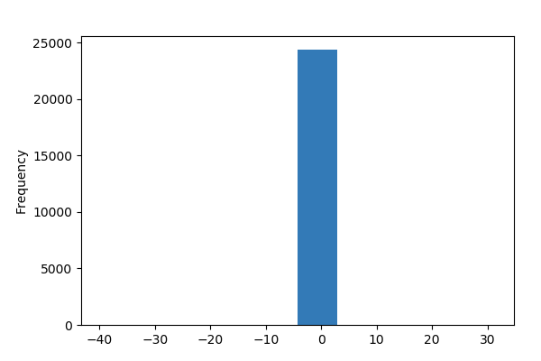

**Common Values**

| Value | Count | Frequency (%) |  |
| --- | --- | --- | --- |
| -1.746453182974011e-08 | 1 | 0.0% |  |
| -1.7274557332158294e-08 | 1 | 0.0% |  |
| 0.001446970318320434 | 1 | 0.0% |  |
| 0.005459388880598089 | 1 | 0.0% |  |
| -1.7447773096251152e-08 | 1 | 0.0% |  |
| 0.06418566565939378 | 1 | 0.0% |  |
| -1.746437738336765e-08 | 1 | 0.0% |  |
| -1.741034126521727e-08 | 1 | 0.0% |  |
| 0.00010680890112917512 | 1 | 0.0% |  |
| -0.008485014009381777 | 1 | 0.0% |  |
| Other values (24356) | 24356 | 100.0% |  |

**Extreme Values**

Minimum 5 values

| Value | Count | Frequency (%) |  |
| --- | --- | --- | --- |
| -39.75748864611742 | 1 | 0.0% |  |
| -1.9570562309824409 | 1 | 0.0% |  |
| -0.4125366162918631 | 1 | 0.0% |  |
| -0.3760645506073108 | 1 | 0.0% |  |
| -0.3683797647321768 | 1 | 0.0% |  |

Maximum 5 values

| Value | Count | Frequency (%) |  |
| --- | --- | --- | --- |
| 2.0893080007774363 | 1 | 0.0% |  |
| 2.4351941529114303 | 1 | 0.0% |  |
| 3.5217756654750945 | 1 | 0.0% |  |
| 19.351696919740373 | 1 | 0.0% |  |
| 31.221395970398422 | 1 | 0.0% |  |

AccelY  
Numeric

| Distinct count | 24366 |
| --- | --- |
| Unique (%) | 100.0% |
| Missing (%) | 0.0% |
| Missing (n) | 0 |
| Infinite (%) | 0.0% |
| Infinite (n) | 0 |

| Mean | 0.00096125 |
| --- | --- |
| Minimum | -1.254 |
| Maximum | 22.376 |
| Zeros (%) | 0.0% |

Toggle details

**Statistics**

Quantile statistics

| Minimum | -1.254 |
| --- | --- |
| 5-th percentile | -0.064415 |
| Q1 | -2.4801e-05 |
| Median | -2.9491e-08 |
| Q3 | 1.6084e-08 |
| 95-th percentile | 0.047031 |
| Maximum | 22.376 |
| Range | 23.63 |
| Interquartile range | 2.4817e-05 |

Descriptive statistics

| Standard deviation | 0.25936 |
| --- | --- |
| Coef of variation | 269.81 |
| Kurtosis | 5183.3 |
| Mean | 0.00096125 |
| MAD | 0.024241 |
| Skewness | 67.135 |
| Sum | 23.422 |
| Variance | 0.067267 |
| Memory size | 190.4 KiB |

**Histogram**

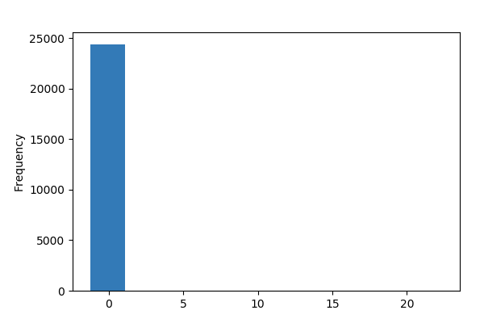

**Common Values**

| Value | Count | Frequency (%) |  |
| --- | --- | --- | --- |
| 0.003462143420583005 | 1 | 0.0% |  |
| -9.98459595020932e-05 | 1 | 0.0% |  |
| -2.8611813553804923e-08 | 1 | 0.0% |  |
| 0.015699597986947932 | 1 | 0.0% |  |
| -2.8719830782147802e-08 | 1 | 0.0% |  |
| -2.924757309673162e-08 | 1 | 0.0% |  |
| -3.005058009874791e-08 | 1 | 0.0% |  |
| -0.02475854879079951 | 1 | 0.0% |  |
| -2.9030925213827998e-08 | 1 | 0.0% |  |
| -3.001398987659068e-08 | 1 | 0.0% |  |
| Other values (24356) | 24356 | 100.0% |  |

**Extreme Values**

Minimum 5 values

| Value | Count | Frequency (%) |  |
| --- | --- | --- | --- |
| -1.2539687956848982 | 1 | 0.0% |  |
| -1.069857321864789 | 1 | 0.0% |  |
| -0.3657358914302178 | 1 | 0.0% |  |
| -0.36506989426321146 | 1 | 0.0% |  |
| -0.36353976948377403 | 1 | 0.0% |  |

Maximum 5 values

| Value | Count | Frequency (%) |  |
| --- | --- | --- | --- |
| 9.056865086624967 | 1 | 0.0% |  |
| 10.782083987167137 | 1 | 0.0% |  |
| 15.397586235382832 | 1 | 0.0% |  |
| 22.093574114460107 | 1 | 0.0% |  |
| 22.37613963951436 | 1 | 0.0% |  |

AccelZ  
Numeric

| Distinct count | 24366 |
| --- | --- |
| Unique (%) | 100.0% |
| Missing (%) | 0.0% |
| Missing (n) | 0 |
| Infinite (%) | 0.0% |
| Infinite (n) | 0 |

| Mean | 6.4069e-07 |
| --- | --- |
| Minimum | -1.0638 |
| Maximum | 0.60552 |
| Zeros (%) | 0.0% |

Toggle details

**Statistics**

Quantile statistics

[output not shown]

Descriptive statistics

| Standard deviation | 0.01332 |
| --- | --- |
| Coef of variation | 20791 |
| Kurtosis | 2140.7 |
| Mean | 6.4069e-07 |
| MAD | 0.0025798 |
| Skewness | -12.757 |
| Sum | 0.015611 |
| Variance | 0.00017743 |
| Memory size | 190.4 KiB |

**Histogram**

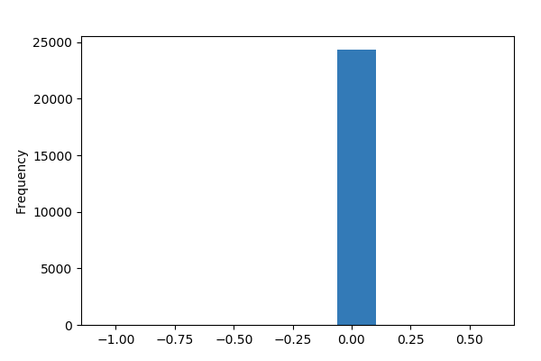

**Common Values**

| Value | Count | Frequency (%) |  |
| --- | --- | --- | --- |
| -1.195611913188856e-10 | 1 | 0.0% |  |
| -0.001754094412357345 | 1 | 0.0% |  |
| 0.09752512089562193 | 1 | 0.0% |  |
| -0.00029366073172716703 | 1 | 0.0% |  |
| -1.4907803941480663e-10 | 1 | 0.0% |  |
| -0.0021683139568335744 | 1 | 0.0% |  |
| -1.1869196084104493e-10 | 1 | 0.0% |  |
| -1.4846694151340075e-10 | 1 | 0.0% |  |
| -0.056162350871365965 | 1 | 0.0% |  |
| 0.008710582748952651 | 1 | 0.0% |  |
| Other values (24356) | 24356 | 100.0% |  |

**Extreme Values**

Minimum 5 values

| Value | Count | Frequency (%) |  |
| --- | --- | --- | --- |
| -1.0638083352201753 | 1 | 0.0% |  |
| -0.4347970858134885 | 1 | 0.0% |  |
| -0.3017101644138986 | 1 | 0.0% |  |
| -0.23095910280569304 | 1 | 0.0% |  |
| -0.16436308989731166 | 1 | 0.0% |  |

Maximum 5 values

| Value | Count | Frequency (%) |  |
| --- | --- | --- | --- |
| 0.22798588474629014 | 1 | 0.0% |  |
| 0.3149893683801103 | 1 | 0.0% |  |
| 0.5045692335129299 | 1 | 0.0% |  |
| 0.551072371193168 | 1 | 0.0% |  |
| 0.6055229934733624 | 1 | 0.0% |  |

AngVelX  
Numeric

| Distinct count | 24366 |
| --- | --- |
| Unique (%) | 100.0% |
| Missing (%) | 0.0% |
| Missing (n) | 0 |
| Infinite (%) | 0.0% |
| Infinite (n) | 0 |

| Mean | 3.4105e-05 |
| --- | --- |
| Minimum | -0.54546 |
| Maximum | 0.024697 |
| Zeros (%) | 0.0% |

Toggle details

**Statistics**

Quantile statistics

| Minimum | -0.54546 |
| --- | --- |
| 5-th percentile | -0.00052052 |
| Q1 | -7.8142e-06 |
| Median | 1.5139e-05 |
| Q3 | 2.0253e-05 |
| 95-th percentile | 0.00096143 |
| Maximum | 0.024697 |
| Range | 0.57016 |
| Interquartile range | 2.8068e-05 |

Descriptive statistics

| Standard deviation | 0.0035807 |
| --- | --- |
| Coef of variation | 104.99 |
| Kurtosis | 22111 |
| Mean | 3.4105e-05 |
| MAD | 0.00030491 |
| Skewness | -145.13 |
| Sum | 0.831 |
| Variance | 1.2821e-05 |
| Memory size | 190.4 KiB |

**Histogram**

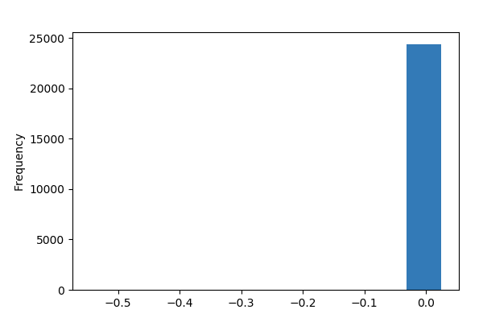

**Common Values**

| Value | Count | Frequency (%) |  |
| --- | --- | --- | --- |
| 1.5544192308496265e-05 | 1 | 0.0% |  |
| -0.0002594094911494302 | 1 | 0.0% |  |
| 1.5442374940744517e-05 | 1 | 0.0% |  |
| 1.5196182382637757e-05 | 1 | 0.0% |  |
| -0.0002743617684795314 | 1 | 0.0% |  |
| -0.000520278498747881 | 1 | 0.0% |  |
| 0.000388442274373545 | 1 | 0.0% |  |
| -0.00010711459659682093 | 1 | 0.0% |  |
| -6.714493298021086e-05 | 1 | 0.0% |  |
| 1.54933827781529e-05 | 1 | 0.0% |  |
| Other values (24356) | 24356 | 100.0% |  |

**Extreme Values**

Minimum 5 values

| Value | Count | Frequency (%) |  |
| --- | --- | --- | --- |
| -0.5454588238245577 | 1 | 0.0% |  |
| -0.034549539228130824 | 1 | 0.0% |  |
| -0.011784306133277906 | 1 | 0.0% |  |
| -0.010499024736192505 | 1 | 0.0% |  |
| -0.008930706031005922 | 1 | 0.0% |  |

Maximum 5 values

| Value | Count | Frequency (%) |  |
| --- | --- | --- | --- |
| 0.014289533158379298 | 1 | 0.0% |  |
| 0.016108033117325463 | 1 | 0.0% |  |
| 0.017613976533560928 | 1 | 0.0% |  |
| 0.02312573912532067 | 1 | 0.0% |  |
| 0.024697309376491252 | 1 | 0.0% |  |

AngVelY  
Numeric

| Distinct count | 24366 |
| --- | --- |
| Unique (%) | 100.0% |
| Missing (%) | 0.0% |
| Missing (n) | 0 |
| Infinite (%) | 0.0% |
| Infinite (n) | 0 |

| Mean | 6.8449e-05 |
| --- | --- |
| Minimum | -0.016366 |
| Maximum | 0.087305 |
| Zeros (%) | 0.0% |

Toggle details

**Statistics**

Quantile statistics

| Minimum | -0.016366 |
| --- | --- |
| 5-th percentile | -0.00073761 |
| Q1 | 1.5254e-05 |
| Median | 6.124e-05 |
| Q3 | 7.0575e-05 |
| 95-th percentile | 0.0007897 |
| Maximum | 0.087305 |
| Range | 0.10367 |
| Interquartile range | 5.532e-05 |

Descriptive statistics

| Standard deviation | 0.00092283 |
| --- | --- |
| Coef of variation | 13.482 |
| Kurtosis | 3292.7 |
| Mean | 6.8449e-05 |
| MAD | 0.0002864 |
| Skewness | 35.478 |
| Sum | 1.6678 |
| Variance | 8.5162e-07 |
| Memory size | 190.4 KiB |

**Histogram**

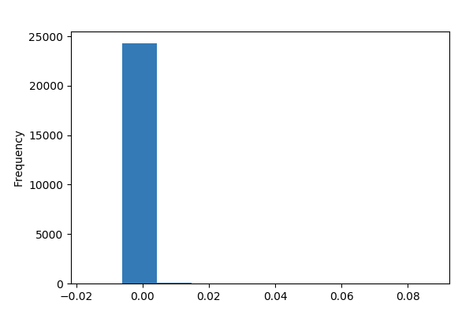

**Common Values**

| Value | Count | Frequency (%) |  |
| --- | --- | --- | --- |
| 6.121514299046295e-05 | 1 | 0.0% |  |
| 0.00016794816944973247 | 1 | 0.0% |  |
| 6.121392959576478e-05 | 1 | 0.0% |  |
| 6.496552755876601e-05 | 1 | 0.0% |  |
| -3.1999565184493075e-05 | 1 | 0.0% |  |
| 6.137654533908532e-05 | 1 | 0.0% |  |
| -0.00010975878414594886 | 1 | 0.0% |  |
| 6.116284269083075e-05 | 1 | 0.0% |  |
| -0.00016325144107632268 | 1 | 0.0% |  |
| 6.130854133794084e-05 | 1 | 0.0% |  |
| Other values (24356) | 24356 | 100.0% |  |

**Extreme Values**

Minimum 5 values

| Value | Count | Frequency (%) |  |
| --- | --- | --- | --- |
| -0.016365728338889066 | 1 | 0.0% |  |
| -0.01042319909635778 | 1 | 0.0% |  |
| -0.008242528644870779 | 1 | 0.0% |  |
| -0.0063531814819688575 | 1 | 0.0% |  |
| -0.005695293900132029 | 1 | 0.0% |  |

Maximum 5 values

| Value | Count | Frequency (%) |  |
| --- | --- | --- | --- |
| 0.008563926581073678 | 1 | 0.0% |  |
| 0.010664368084180892 | 1 | 0.0% |  |
| 0.0112077618328989 | 1 | 0.0% |  |
| 0.01589593645135141 | 1 | 0.0% |  |
| 0.08730479931354382 | 1 | 0.0% |  |

AngVelZ  
Numeric

| Distinct count | 24366 |
| --- | --- |
| Unique (%) | 100.0% |
| Missing (%) | 0.0% |
| Missing (n) | 0 |
| Infinite (%) | 0.0% |
| Infinite (n) | 0 |

| Mean | -0.069091 |
| --- | --- |
| Minimum | -1.4171 |
| Maximum | 1.4465 |
| Zeros (%) | 0.0% |

Toggle details

**Statistics**

Quantile statistics

| Minimum | -1.4171 |
| --- | --- |
| 5-th percentile | -0.60971 |
| Q1 | -0.021398 |
| Median | -0.00026028 |
| Q3 | -0.00025582 |
| 95-th percentile | 0.12586 |
| Maximum | 1.4465 |
| Range | 2.8636 |
| Interquartile range | 0.021142 |

Descriptive statistics

| Standard deviation | 0.28601 |
| --- | --- |
| Coef of variation | -4.1396 |
| Kurtosis | 10.594 |
| Mean | -0.069091 |
| MAD | 0.15325 |
| Skewness | -2.2455 |
| Sum | -1683.5 |
| Variance | 0.0818 |
| Memory size | 190.4 KiB |

**Histogram**

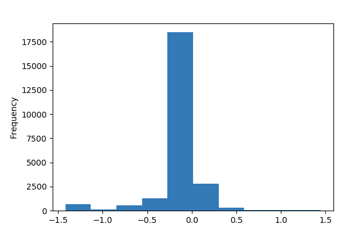

**Common Values**

| Value | Count | Frequency (%) |  |
| --- | --- | --- | --- |
| -0.0002563163149644197 | 1 | 0.0% |  |
| -0.0002562364314151348 | 1 | 0.0% |  |
| -0.00025875560423817084 | 1 | 0.0% |  |
| -0.19533282071132926 | 1 | 0.0% |  |
| -0.0002566346575713437 | 1 | 0.0% |  |
| -0.04565692323499063 | 1 | 0.0% |  |
| -0.26702986211014634 | 1 | 0.0% |  |
| -0.05732813321068745 | 1 | 0.0% |  |
| -0.00025865367726490764 | 1 | 0.0% |  |
| -0.04563197654563846 | 1 | 0.0% |  |
| Other values (24356) | 24356 | 100.0% |  |

**Extreme Values**

Minimum 5 values

| Value | Count | Frequency (%) |  |
| --- | --- | --- | --- |
| -1.4171083283634784 | 1 | 0.0% |  |
| -1.4169928788458976 | 1 | 0.0% |  |
| -1.4168111096045997 | 1 | 0.0% |  |
| -1.4167212462545802 | 1 | 0.0% |  |
| -1.4166324231444567 | 1 | 0.0% |  |

Maximum 5 values

| Value | Count | Frequency (%) |  |
| --- | --- | --- | --- |
| 1.4173029758512083 | 1 | 0.0% |  |
| 1.42383240406083 | 1 | 0.0% |  |
| 1.429765106465766 | 1 | 0.0% |  |
| 1.4373441078535445 | 1 | 0.0% |  |
| 1.4464944842028506 | 1 | 0.0% |  |

CurrentVelX  
Numeric

| Distinct count | 24346 |
| --- | --- |
| Unique (%) | 99.9% |
| Missing (%) | 0.0% |
| Missing (n) | 2 |
| Infinite (%) | 0.0% |
| Infinite (n) | 0 |

| Mean | 0.064968 |
| --- | --- |
| Minimum | -0.016906 |
| Maximum | 0.46931 |
| Zeros (%) | 0.0% |

Toggle details

**Statistics**

Quantile statistics

| Minimum | -0.016906 |
| --- | --- |
| 5-th percentile | -0.0085136 |
| Q1 | -4.6734e-07 |
| Median | 0.0015144 |
| Q3 | 0.12025 |
| 95-th percentile | 0.2439 |
| Maximum | 0.46931 |
| Range | 0.48622 |
| Interquartile range | 0.12025 |

Descriptive statistics

| Standard deviation | 0.099604 |
| --- | --- |
| Coef of variation | 1.5331 |
| Kurtosis | 2.5542 |
| Mean | 0.064968 |
| MAD | 0.07994 |
| Skewness | 1.644 |
| Sum | 1582.9 |
| Variance | 0.0099209 |
| Memory size | 190.4 KiB |

**Histogram**

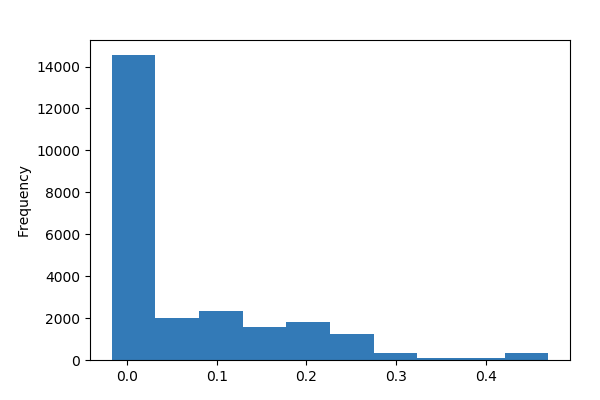

**Common Values**

| Value | Count | Frequency (%) |  |
| --- | --- | --- | --- |
| 0.002707248576109948 | 3 | 0.0% |  |
| 0.25788793381650926 | 2 | 0.0% |  |
| 0.0027072428427801754 | 2 | 0.0% |  |
| 0.002707268722609429 | 2 | 0.0% |  |
| 0.15173987250503418 | 2 | 0.0% |  |
| 0.22651725652635946 | 2 | 0.0% |  |
| 0.002707205118146197 | 2 | 0.0% |  |
| 0.0027072788704086636 | 2 | 0.0% |  |
| 0.0027072861806178585 | 2 | 0.0% |  |
| 0.08960400107628869 | 2 | 0.0% |  |
| Other values (24335) | 24343 | 99.9% |  |

**Extreme Values**

Minimum 5 values

| Value | Count | Frequency (%) |  |
| --- | --- | --- | --- |
| -0.0169062186918142 | 1 | 0.0% |  |
| -0.016897087710394654 | 1 | 0.0% |  |
| -0.016871133087424394 | 1 | 0.0% |  |
| -0.0168710550417893 | 1 | 0.0% |  |
| -0.01686548970104443 | 1 | 0.0% |  |

Maximum 5 values

| Value | Count | Frequency (%) |  |
| --- | --- | --- | --- |
| 0.46920422025697267 | 1 | 0.0% |  |
| 0.46923098930208956 | 1 | 0.0% |  |
| 0.4692430488015065 | 1 | 0.0% |  |
| 0.46927499909545717 | 1 | 0.0% |  |
| 0.4693100995576776 | 1 | 0.0% |  |

CurrentVelY  
Numeric

| Distinct count | 24343 |
| --- | --- |
| Unique (%) | 99.9% |
| Missing (%) | 0.0% |
| Missing (n) | 2 |
| Infinite (%) | 0.0% |
| Infinite (n) | 0 |

| Mean | 0.00077041 |
| --- | --- |
| Minimum | -0.17316 |
| Maximum | 0.20052 |
| Zeros (%) | 0.0% |

Toggle details

**Statistics**

Quantile statistics

| Minimum | -0.17316 |
| --- | --- |
| 5-th percentile | -0.10915 |
| Q1 | -0.0036967 |
| Median | -9.8716e-07 |
| Q3 | -8.8454e-08 |
| 95-th percentile | 0.17166 |
| Maximum | 0.20052 |
| Range | 0.37368 |
| Interquartile range | 0.0036966 |

Descriptive statistics

| Standard deviation | 0.065319 |
| --- | --- |
| Coef of variation | 84.785 |
| Kurtosis | 2.4039 |
| Mean | 0.00077041 |
| MAD | 0.035272 |
| Skewness | 0.91502 |
| Sum | 18.77 |
| Variance | 0.0042666 |
| Memory size | 190.4 KiB |

**Histogram**

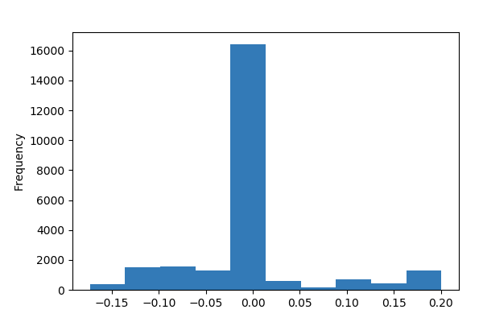

**Common Values**

| Value | Count | Frequency (%) |  |
| --- | --- | --- | --- |
| -0.000987771702142317 | 3 | 0.0% |  |
| 0.1464052738984977 | 2 | 0.0% |  |
| 0.010535720260499416 | 2 | 0.0% |  |
| -0.0009877601818252396 | 2 | 0.0% |  |
| 0.03859923664817698 | 2 | 0.0% |  |
| -0.11746023836166436 | 2 | 0.0% |  |
| -0.10915280825083061 | 2 | 0.0% |  |
| -0.07711404601091638 | 2 | 0.0% |  |
| 0.038601541699583464 | 2 | 0.0% |  |
| -0.0009877775213865078 | 2 | 0.0% |  |
| Other values (24332) | 24343 | 99.9% |  |

**Extreme Values**

Minimum 5 values

| Value | Count | Frequency (%) |  |
| --- | --- | --- | --- |
| -0.1731643116053379 | 1 | 0.0% |  |
| -0.1729820469295721 | 1 | 0.0% |  |
| -0.1729204929964388 | 1 | 0.0% |  |
| -0.17284917684271583 | 1 | 0.0% |  |
| -0.17281201413041247 | 1 | 0.0% |  |

Maximum 5 values

| Value | Count | Frequency (%) |  |
| --- | --- | --- | --- |
| 0.19937273610250944 | 1 | 0.0% |  |
| 0.19966447249349534 | 1 | 0.0% |  |
| 0.19989065459491107 | 1 | 0.0% |  |
| 0.20026768172736154 | 1 | 0.0% |  |
| 0.2005176561359699 | 1 | 0.0% |  |

CurrentVelZ  
Numeric

| Distinct count | 24346 |
| --- | --- |
| Unique (%) | 99.9% |
| Missing (%) | 0.0% |
| Missing (n) | 2 |
| Infinite (%) | 0.0% |
| Infinite (n) | 0 |

| Mean | 0.00021767 |
| --- | --- |
| Minimum | -0.0017408 |
| Maximum | 0.0028662 |
| Zeros (%) | 0.0% |

Toggle details

**Statistics**

Quantile statistics

| Minimum | -0.0017408 |
| --- | --- |
| 5-th percentile | -0.0002333 |
| Q1 | -1.6058e-05 |
| Median | 1.565e-08 |
| Q3 | 5.2335e-05 |
| 95-th percentile | 0.0017076 |
| Maximum | 0.0028662 |
| Range | 0.0046071 |
| Interquartile range | 6.8392e-05 |

Descriptive statistics

| Standard deviation | 0.00059634 |
| --- | --- |
| Coef of variation | 2.7397 |
| Kurtosis | 2.8404 |
| Mean | 0.00021767 |
| MAD | 0.00040385 |
| Skewness | 2.06 |
| Sum | 5.3032 |
| Variance | 3.5563e-07 |
| Memory size | 190.4 KiB |

**Histogram**

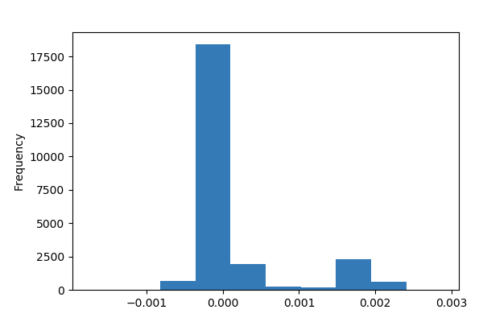

**Common Values**

| Value | Count | Frequency (%) |  |
| --- | --- | --- | --- |
| -3.599076125756209e-05 | 3 | 0.0% |  |
| 1.5686636713593163e-08 | 2 | 0.0% |  |
| 1.7152955601067563e-08 | 2 | 0.0% |  |
| -3.599062147691284e-05 | 2 | 0.0% |  |
| -3.599062610374916e-05 | 2 | 0.0% |  |
| 4.733078876296189e-05 | 2 | 0.0% |  |
| -0.000442438137656723 | 2 | 0.0% |  |
| -3.599080027088074e-05 | 2 | 0.0% |  |
| 2.4022552594994673e-05 | 2 | 0.0% |  |
| 2.4070043555108256e-05 | 2 | 0.0% |  |
| Other values (24335) | 24343 | 99.9% |  |

**Extreme Values**

Minimum 5 values

| Value | Count | Frequency (%) |  |
| --- | --- | --- | --- |
| -0.0017408302600390845 | 1 | 0.0% |  |
| -0.0016308019501061815 | 1 | 0.0% |  |
| -0.0008288867210763238 | 1 | 0.0% |  |
| -0.0007685681882752307 | 1 | 0.0% |  |
| -0.0007089239878419516 | 1 | 0.0% |  |

Maximum 5 values

| Value | Count | Frequency (%) |  |
| --- | --- | --- | --- |
| 0.0022883257708456654 | 1 | 0.0% |  |
| 0.0022892738956616326 | 1 | 0.0% |  |
| 0.0024477765966982425 | 1 | 0.0% |  |
| 0.002693447896797985 | 1 | 0.0% |  |
| 0.0028662264777917588 | 1 | 0.0% |  |

DeltaLinVelX  
Highly correlated

*This variable is highly correlated with `AccelX` and should be ignored for analysis*

| Correlation | 0.99942 |
| --- | --- |

DeltaLinVelY  
Highly correlated

*This variable is highly correlated with `AccelY` and should be ignored for analysis*

| Correlation | 0.98892 |
| --- | --- |

DeltaLinVelZ  
Highly correlated

*This variable is highly correlated with `AccelZ` and should be ignored for analysis*

| Correlation | 0.9735 |
| --- | --- |

DeltaPosX  
Highly correlated

*This variable is highly correlated with `CurrentVelX` and should be ignored for analysis*

| Correlation | 0.98228 |
| --- | --- |

DeltaPosY  
Highly correlated

*This variable is highly correlated with `CurrentVelY` and should be ignored for analysis*

| Correlation | 0.98538 |
| --- | --- |

DeltaPosZ  
Highly correlated

*This variable is highly correlated with `CurrentVelZ` and should be ignored for analysis*

| Correlation | 0.98385 |
| --- | --- |

DeltaT  
Numeric

| Distinct count | 1115 |
| --- | --- |
| Unique (%) | 4.6% |
| Missing (%) | 0.0% |
| Missing (n) | 2 |
| Infinite (%) | 0.0% |
| Infinite (n) | 0 |

| Mean | 0.0050006 |
| --- | --- |
| Minimum | -1.128e-13 |
| Maximum | 0.017 |
| Zeros (%) | 0.0% |

Toggle details

**Statistics**

Quantile statistics

| Minimum | -1.128e-13 |
| --- | --- |
| 5-th percentile | 0.004 |
| Q1 | 0.005 |
| Median | 0.005 |
| Q3 | 0.005 |
| 95-th percentile | 0.006 |
| Maximum | 0.017 |
| Range | 0.017 |
| Interquartile range | 1.4552e-13 |

Descriptive statistics

| Standard deviation | 0.00086834 |
| --- | --- |
| Coef of variation | 0.17365 |
| Kurtosis | 24.357 |
| Mean | 0.0050006 |
| MAD | 0.00030501 |
| Skewness | 1.0898 |
| Sum | 121.83 |
| Variance | 7.5401e-07 |
| Memory size | 190.4 KiB |

**Histogram**

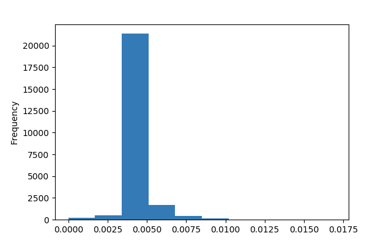

**Common Values**

| Value | Count | Frequency (%) |  |
| --- | --- | --- | --- |
| 0.0050000000000473 | 795 | 3.3% |  |
| 0.004999999999929061 | 757 | 3.1% |  |
| 0.004999999999938165 | 697 | 2.9% |  |
| 0.004999999999919957 | 676 | 2.8% |  |
| 0.005000000000029092 | 672 | 2.8% |  |
| 0.005000000000038196 | 660 | 2.7% |  |
| 0.005000000000056404 | 585 | 2.4% |  |
| 0.0049999999999108535 | 573 | 2.4% |  |
| 0.005000000000065508 | 571 | 2.3% |  |
| 0.0050000000000199885 | 567 | 2.3% |  |
| Other values (1104) | 17811 | 73.1% |  |

**Extreme Values**

Minimum 5 values

| Value | Count | Frequency (%) |  |
| --- | --- | --- | --- |
| -1.127986593019159e-13 | 1 | 0.0% |  |
| -1.0735856648125264e-13 | 3 | 0.0% |  |
| -1.0547118733938987e-13 | 1 | 0.0% |  |
| -9.825473767932635e-14 | 1 | 0.0% |  |
| -9.822698210371072e-14 | 1 | 0.0% |  |

Maximum 5 values

| Value | Count | Frequency (%) |  |
| --- | --- | --- | --- |
| 0.014999999999892655 | 1 | 0.0% |  |
| 0.014999999999936342 | 1 | 0.0% |  |
| 0.015000000000007285 | 1 | 0.0% |  |
| 0.015000000000092772 | 1 | 0.0% |  |
| 0.01700000000002 | 1 | 0.0% |  |

Nanosecs  
Numeric

| Distinct count | 866 |
| --- | --- |
| Unique (%) | 3.6% |
| Missing (%) | 0.0% |
| Missing (n) | 0 |
| Infinite (%) | 0.0% |
| Infinite (n) | 0 |

| Mean | 500500000 |
| --- | --- |
| Minimum | 1000000 |
| Maximum | 999000000 |
| Zeros (%) | 0.0% |

Toggle details

**Statistics**

Quantile statistics

| Minimum | 1000000 |
| --- | --- |
| 5-th percentile | 48000000 |
| Q1 | 248000000 |
| Median | 503000000 |
| Q3 | 752000000 |
| 95-th percentile | 949000000 |
| Maximum | 999000000 |
| Range | 998000000 |
| Interquartile range | 504000000 |

Descriptive statistics

| Standard deviation | 288860000 |
| --- | --- |
| Coef of variation | 0.57714 |
| Kurtosis | -1.2021 |
| Mean | 500500000 |
| MAD | 250240000 |
| Skewness | -0.00091758 |
| Sum | 12195000000000 |
| Variance | 8.3438e+16 |
| Memory size | 190.4 KiB |

**Histogram**

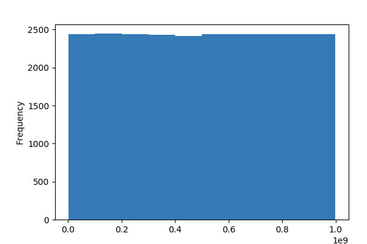

**Common Values**

| Value | Count | Frequency (%) |  |
| --- | --- | --- | --- |
| 368000000.0 | 117 | 0.5% |  |
| 718000000.0 | 117 | 0.5% |  |
| 818000000.0 | 116 | 0.5% |  |
| 223000000.0 | 116 | 0.5% |  |
| 178000000.0 | 116 | 0.5% |  |
| 208000000.0 | 116 | 0.5% |  |
| 823000000.0 | 116 | 0.5% |  |
| 618000000.0 | 116 | 0.5% |  |
| 73000000.0 | 115 | 0.5% |  |
| 23000000.0 | 115 | 0.5% |  |
| Other values (856) | 23206 | 95.2% |  |

**Extreme Values**

Minimum 5 values

| Value | Count | Frequency (%) |  |
| --- | --- | --- | --- |
| 1000000.0 | 3 | 0.0% |  |
| 2000000.0 | 11 | 0.0% |  |
| 3000000.0 | 108 | 0.4% |  |
| 4000000.0 | 2 | 0.0% |  |
| 5000000.0 | 1 | 0.0% |  |

Maximum 5 values

| Value | Count | Frequency (%) |  |
| --- | --- | --- | --- |
| 993000000.0 | 111 | 0.5% |  |
| 994000000.0 | 5 | 0.0% |  |
| 997000000.0 | 5 | 0.0% |  |
| 998000000.0 | 113 | 0.5% |  |
| 999000000.0 | 1 | 0.0% |  |

OrientW  
Highly correlated

*This variable is highly correlated with `OrientY` and should be ignored for analysis*

| Correlation | 1 |
| --- | --- |

OrientX  
Numeric

| Distinct count | 24366 |
| --- | --- |
| Unique (%) | 100.0% |
| Missing (%) | 0.0% |
| Missing (n) | 0 |
| Infinite (%) | 0.0% |
| Infinite (n) | 0 |

| Mean | 0.00065202 |
| --- | --- |
| Minimum | -0.0015875 |
| Maximum | 0.0015932 |
| Zeros (%) | 0.0% |

Toggle details

**Statistics**

Quantile statistics

| Minimum | -0.0015875 |
| --- | --- |
| 5-th percentile | -0.0015319 |
| Q1 | 0.0010258 |
| Median | 0.0010467 |
| Q3 | 0.0010567 |
| 95-th percentile | 0.0015839 |
| Maximum | 0.0015932 |
| Range | 0.0031806 |
| Interquartile range | 3.0924e-05 |

Descriptive statistics

| Standard deviation | 0.00098767 |
| --- | --- |
| Coef of variation | 1.5148 |
| Kurtosis | 0.50821 |
| Mean | 0.00065202 |
| MAD | 0.00076491 |
| Skewness | -1.481 |
| Sum | 15.887 |
| Variance | 9.7548e-07 |
| Memory size | 190.4 KiB |

**Histogram**

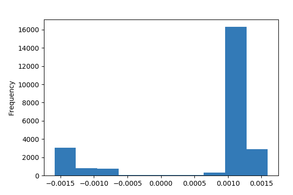

**Common Values**

| Value | Count | Frequency (%) |  |
| --- | --- | --- | --- |
| 0.001164026844700786 | 1 | 0.0% |  |
| 0.0010497134612046301 | 1 | 0.0% |  |
| 0.0010467999112778689 | 1 | 0.0% |  |
| 0.0010447139284719572 | 1 | 0.0% |  |
| 0.0010448239580947737 | 1 | 0.0% |  |
| 0.001067030151611307 | 1 | 0.0% |  |
| -0.0008643651856546399 | 1 | 0.0% |  |
| 0.0010605667637794422 | 1 | 0.0% |  |
| 0.0015902892805486153 | 1 | 0.0% |  |
| 0.0013711672942221676 | 1 | 0.0% |  |
| Other values (24356) | 24356 | 100.0% |  |

**Extreme Values**

Minimum 5 values

| Value | Count | Frequency (%) |  |
| --- | --- | --- | --- |
| -0.001587456823741818 | 1 | 0.0% |  |
| -0.0015866672304289359 | 1 | 0.0% |  |
| -0.0015865970613301384 | 1 | 0.0% |  |
| -0.0015865537570870422 | 1 | 0.0% |  |
| -0.0015865527434695042 | 1 | 0.0% |  |

Maximum 5 values

| Value | Count | Frequency (%) |  |
| --- | --- | --- | --- |
| 0.0015927731925894015 | 1 | 0.0% |  |
| 0.0015928422141396619 | 1 | 0.0% |  |
| 0.0015930479204248587 | 1 | 0.0% |  |
| 0.0015931168763226025 | 1 | 0.0% |  |
| 0.0015931543518272813 | 1 | 0.0% |  |

OrientY  
Numeric

| Distinct count | 24366 |
| --- | --- |
| Unique (%) | 100.0% |
| Missing (%) | 0.0% |
| Missing (n) | 0 |
| Infinite (%) | 0.0% |
| Infinite (n) | 0 |

| Mean | 0.00057075 |
| --- | --- |
| Minimum | -0.0015896 |
| Maximum | 0.0012322 |
| Zeros (%) | 0.0% |

Toggle details

**Statistics**

Quantile statistics

| Minimum | -0.0015896 |
| --- | --- |
| 5-th percentile | -0.0012795 |
| Q1 | -0.00013808 |
| Median | 0.0011968 |
| Q3 | 0.0011998 |
| 95-th percentile | 0.0012032 |
| Maximum | 0.0012322 |
| Range | 0.0028218 |
| Interquartile range | 0.0013379 |

Descriptive statistics

| Standard deviation | 0.00089713 |
| --- | --- |
| Coef of variation | 1.5718 |
| Kurtosis | -0.47606 |
| Mean | 0.00057075 |
| MAD | 0.00079099 |
| Skewness | -1.0371 |
| Sum | 13.907 |
| Variance | 8.0484e-07 |
| Memory size | 190.4 KiB |

**Histogram**

[8 more figures not shown]

Sample

| Seq | Secs | Nanosecs | OrientX | OrientY | OrientZ | OrientW | AngVelX | AngVelY | AngVelZ | AccelX | AccelY | AccelZ | AccelMag | DeltaT | DeltaLinVelX | CurrentVelX | DeltaLinVelY | CurrentVelY | DeltaLinVelZ | CurrentVelZ | DeltaPosX | PosX | DeltaPosY | PosY | DeltaPosZ | PosZ |
| --- | --- | --- | --- | --- | --- | --- | --- | --- | --- | --- | --- | --- | --- | --- | --- | --- | --- | --- | --- | --- | --- | --- | --- | --- | --- | --- |
| 0.0 | 1324.0 | 514000000.0 | 0.001044 | 0.001202 | -0.657056 | 0.753840 | 0.000015 | 0.000061 | -0.000262 | 7.743543e-08 | 4.039488e-08 | 4.467783e-06 | 4.468636e-06 | 0.004 | 3.097417e-10 | 0.000000e+00 | 1.615795e-10 | 0.000000e+00 | 1.787113e-08 | 0.000000e+00 | 0.000000e+00 | 0.000000e+00 | 0.000000e+00 | 0.000000e+00 | 0.000000e+00 | 0.000000e+00 |
| 1.0 | 1324.0 | 518000000.0 | 0.001044 | 0.001202 | -0.657056 | 0.753840 | 0.000015 | 0.000061 | -0.000262 | -1.734290e-08 | -3.004739e-08 | -1.162637e-10 | 3.469345e-08 | 0.004 | -6.937161e-11 | 3.097417e-10 | -1.201896e-10 | 1.615795e-10 | -4.650549e-13 | 1.787113e-08 | 1.238967e-12 | 0.000000e+00 | 6.463182e-13 | 0.000000e+00 | 7.148452e-11 | 0.000000e+00 |
| 2.0 | 1324.0 | 523000000.0 | 0.001044 | 0.001202 | -0.657057 | 0.753839 | 0.000015 | 0.000061 | -0.000262 | -1.734162e-08 | -3.005706e-08 | -1.165548e-10 | 3.470118e-08 | 0.005 | -8.670808e-11 | 2.403701e-10 | -1.502853e-10 | 4.138997e-11 | -5.827741e-13 | 1.787067e-08 | 1.201851e-12 | 1.238967e-12 | 2.069499e-13 | 6.463182e-13 | 8.935333e-11 | 7.148452e-11 |
| 3.0 | 1324.0 | 528000000.0 | 0.001044 | 0.001202 | -0.657057 | 0.753839 | 0.000015 | 0.000061 | -0.000262 | -1.734996e-08 | -3.005905e-08 | -1.174085e-10 | 3.470708e-08 | 0.005 | -8.674979e-11 | 1.536620e-10 | -1.502953e-10 | -1.088953e-10 | -5.870423e-13 | 1.787008e-08 | 7.683101e-13 | 2.440817e-12 | -5.444765e-13 | 8.532680e-13 | 8.935041e-11 | 1.608379e-10 |
| 4.0 | 1324.0 | 533000000.0 | 0.001044 | 0.001202 | -0.657058 | 0.753839 | 0.000015 | 0.000061 | -0.000262 | -1.735201e-08 | -3.005913e-08 | -1.175825e-10 | 3.470817e-08 | 0.005 | -8.676003e-11 | 6.691223e-11 | -1.502956e-10 | -2.591906e-10 | -5.879125e-13 | 1.786950e-08 | 3.345612e-13 | 3.209128e-12 | -1.295953e-12 | 3.087915e-13 | 8.934748e-11 | 2.501883e-10 |

```python
pp.ProfileReport(df)
```

```python
df.sum()
# since the x and y accel is positive sum,
# the robot must have been moving faster at
# the end of recoridng than the start.
```

```
Secs            3.374528e+07
Nanosecs        1.219514e+13
OrientX         1.588716e+01
OrientY         1.390694e+01
OrientZ        -9.988965e+03
OrientW         8.725545e+03
AngVelX         8.309985e-01
AngVelY         1.667822e+00
AngVelZ        -1.683466e+03
AccelX          5.148171e+01
AccelY          2.342185e+01
AccelZ          1.561107e-02
AccelMag        1.002100e+03
DeltaT          1.218340e+02
DeltaLinVelX    2.578879e-01
CurrentVelX     1.582875e+03
DeltaLinVelY    1.464053e-01
CurrentVelY     1.877020e+01
DeltaLinVelZ    1.643574e-03
CurrentVelZ     5.303193e+00
DeltaPosX       7.914551e+00
PosX            2.877792e+04
DeltaPosY       9.398165e-02
PosY           -8.030581e+03
DeltaPosZ       2.652648e-02
PosZ            3.394445e+01
dtype: float64
```

Below is a graph showing acceleration in X,Y,X, and the scalar magnitude of acceleration vector over time.

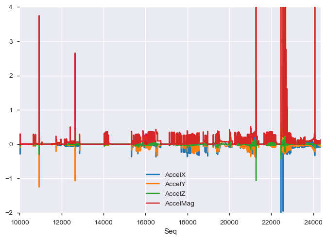

```python
ax3 = df[['AccelX', 'AccelY', 'AccelZ', 'AccelMag']].plot(ylim=(-2, 4), xlim=(10000, None))
```

Below is a graph showing acceleration in X,Y,Z directions over a zoomed in subset of time.

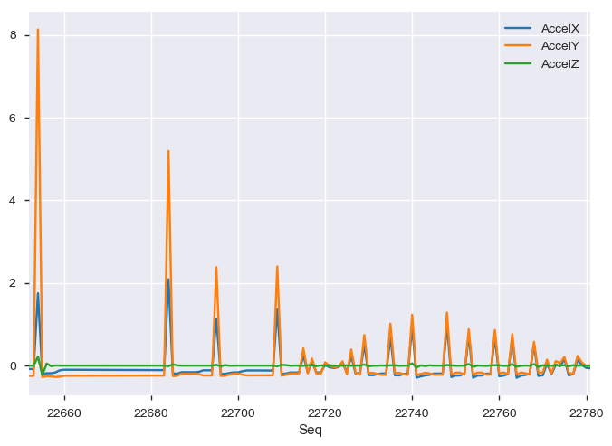

```python
start, end = 22650, 22780
_ = df.iloc[start:end][['AccelX', 'AccelY', 'AccelZ']].plot()
```

Below is a comparison of the acceleration and angular velocity of the robot in the x direction over time. Differing axis are used as the units and scales are very different.

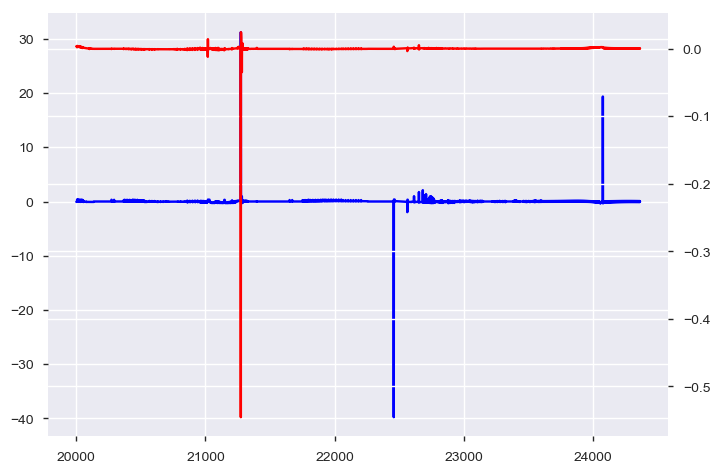

```python
start=20000
dfFocused = df[start:]
fig, ax1 = plt.subplots()
ax1.plot(dfFocused.index, dfFocused.AccelX, color='blue')
# ax1.plot(dfFocused.index, dfFocused.AccelY, color='red')
# ax1.plot(dfFocused.index, dfFocused.AccelZ, color='green')
ax2 = ax1.twinx()
_ = ax2.plot(dfFocused.index, dfFocused.AngVelX, color='red')
# ax2.plot(dfFocused.index, dfFocused.AngVelY, color='red')
# ax2.plot(dfFocused.index, dfFocused.AngVelZ, color='green')
```

Below is a graph of position, velocity, and acceleration of the robot in the x direction over time.

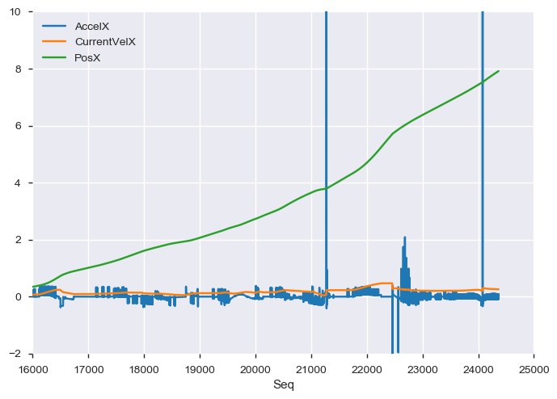

```python
ax4 = df[['AccelX', 'CurrentVelX', 'PosX']].plot(xlim=(16000, 25000), ylim=(-2,10))
```

Below is a zoomed in version of the graph above, so its easier to see how the acceleration interacts with velocity and position.

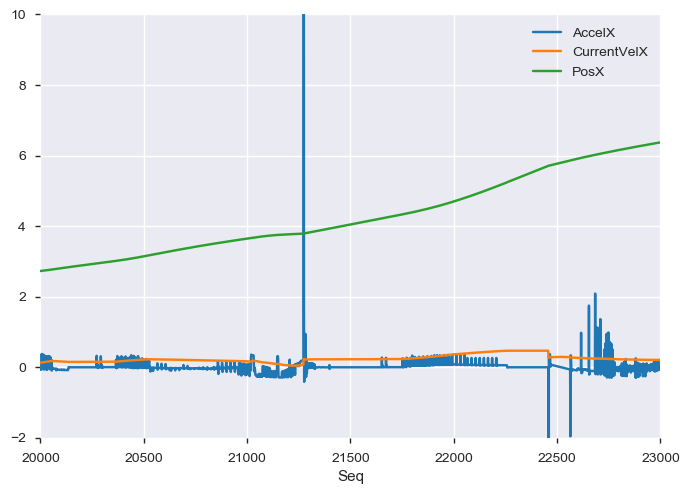

```python
ax5 = df[['AccelX', 'CurrentVelX', 'PosX']].plot(xlim=(20000, 23000), ylim=(-2,10))
```